# **Twitter US Airline Sentiment**

## **Context:**

Twitter possesses 330 million monthly active users, which allows businesses to reach a broad population and connect with customers without intermediaries. On the other hand, there’s so much information that it’s difficult for brands to quickly detect negative social mentions that could harm their business.

That's why sentiment analysis/classification, which involves monitoring emotions in conversations on social media platforms, has become a key strategy in social media marketing.

Listening to how customers feel about the product/service on Twitter allows companies to understand their audience, keep on top of what’s being said about their brand and their competitors, and discover new trends in the industry.

However, this needs to be done periodically. Otherwise, the analysis will be stale and irrelevant. Also, it should be done for a well defined dataset - either segment tweets by geography or by demographic parameters. Otherwise, the computational effort will be high and the results will not be effective.

Also, analyzing the data sliced by airlines, reveals where a particular airline lags behind. This will help the management recognize and work on the areas of improvement.

## **Purpose:**

The purpose of this analysis is to explore the numerous NLP features and build a classification model where we will be able to tag the tweets as positive or negative. Listening to how customers feel about the product/service on Twitter allows companies to understand their audience, keep on top of what’s being said about their brand and their competitors. We will also use word clouds to discover new trends in the industry.

## **Data description:**

A sentiment analysis job about the problems of each major U.S. airline. Twitter data was scraped from February of 2015 and contributors were asked to first classify positive, negative, and neutral tweets, followed by categorizing negative reasons (such as "late flight" or "rude service").

## Dataset:

The dataset has the following columns:

`tweet_id`  
`airline_sentiment`  
`airline_sentiment_confidence`  
`negativereason`  
`negativereason_confidence`  
`airline`  
`airline_sentiment_gold`  
`name`  
`negativereason_gold`  
`retweet_count`  
`text`  
`tweet_coord`  
`tweet_created`  
`tweet_location`  
`user_timezone`  
`text` is the important field here. This is the target for NLP analysis and sentiment analysis.

```python
# install and import necessary libraries.

!pip install contractions

import re, string, unicodedata                          # Import Regex, string and unicodedata.
import contractions                                     # Import contractions library.
from bs4 import BeautifulSoup                           # Import BeautifulSoup.

import numpy as np                                      # Import numpy.
import pandas as pd                                     # Import pandas.
import nltk                                             # Import Natural Language Tool-Kit.
import wordcloud

nltk.download('stopwords')                              # Download Stopwords.
nltk.download('punkt')
nltk.download('wordnet')

from nltk.corpus import stopwords                       # Import stopwords.
from nltk.tokenize import word_tokenize, sent_tokenize  # Import Tokenizer.
from nltk.stem.wordnet import WordNetLemmatizer         # Import Lemmatizer.
import matplotlib.pyplot as plt                         # Import plt for visualization
import seaborn as sns
from nltk.sentiment.vader import SentimentIntensityAnalyzer
from sklearn.ensemble import RandomForestClassifier
from sklearn.model_selection import cross_val_score
from sklearn.model_selection import train_test_split
from sklearn.feature_extraction.text import TfidfVectorizer
from sklearn import metrics
from sklearn.metrics import confusion_matrix
from sklearn.ensemble import RandomForestClassifier
from sklearn.model_selection import cross_val_score
from sklearn.feature_extraction.text import CountVectorizer
from sklearn.metrics import accuracy_score
from textblob import TextBlob
from wordcloud import WordCloud
from google.colab import drive
import warnings
warnings.simplefilter(action='ignore', category=FutureWarning)
```

Read in the data file

```python
drive.mount('/content/drive')
data=pd.read_csv('/content/drive/MyDrive/nlp_w2/Tweets.csv')
```

Look at the # of rows and columns

```python
data.shape                                               # print shape of data.
```

```
(14640, 15)
```

```python
data.head()                                              # Print first 5 rows of data.
```

|  | tweet_id | airline_sentiment | airline_sentiment_confidence | negativereason | negativereason_confidence | airline | airline_sentiment_gold | name | negativereason_gold | retweet_count | text | tweet_coord | tweet_created | tweet_location | user_timezone |
| --- | --- | --- | --- | --- | --- | --- | --- | --- | --- | --- | --- | --- | --- | --- | --- |
| 0 | 570306133677760513 | neutral | 1.0000 | NaN | NaN | Virgin America | NaN | cairdin | NaN | 0 | @VirginAmerica What @dhepburn said. | NaN | 2015-02-24 11:35:52 -0800 | NaN | Eastern Time (US & Canada) |
| 1 | 570301130888122368 | positive | 0.3486 | NaN | 0.0000 | Virgin America | NaN | jnardino | NaN | 0 | @VirginAmerica plus you've added commercials t... | NaN | 2015-02-24 11:15:59 -0800 | NaN | Pacific Time (US & Canada) |
| 2 | 570301083672813571 | neutral | 0.6837 | NaN | NaN | Virgin America | NaN | yvonnalynn | NaN | 0 | @VirginAmerica I didn't today... Must mean I n... | NaN | 2015-02-24 11:15:48 -0800 | Lets Play | Central Time (US & Canada) |
| 3 | 570301031407624196 | negative | 1.0000 | Bad Flight | 0.7033 | Virgin America | NaN | jnardino | NaN | 0 | @VirginAmerica it's really aggressive to blast... | NaN | 2015-02-24 11:15:36 -0800 | NaN | Pacific Time (US & Canada) |
| 4 | 570300817074462722 | negative | 1.0000 | Can't Tell | 1.0000 | Virgin America | NaN | jnardino | NaN | 0 | @VirginAmerica and it's a really big bad thing... | NaN | 2015-02-24 11:14:45 -0800 | NaN | Pacific Time (US & Canada) |

```python
# Print last 5 rows of data.
data.tail()
```

|  | tweet_id | airline_sentiment | airline_sentiment_confidence | negativereason | negativereason_confidence | airline | airline_sentiment_gold | name | negativereason_gold | retweet_count | text | tweet_coord | tweet_created | tweet_location | user_timezone |
| --- | --- | --- | --- | --- | --- | --- | --- | --- | --- | --- | --- | --- | --- | --- | --- |
| 14635 | 569587686496825344 | positive | 0.3487 | NaN | 0.0000 | American | NaN | KristenReenders | NaN | 0 | @AmericanAir thank you we got on a different f... | NaN | 2015-02-22 12:01:01 -0800 | NaN | NaN |
| 14636 | 569587371693355008 | negative | 1.0000 | Customer Service Issue | 1.0000 | American | NaN | itsropes | NaN | 0 | @AmericanAir leaving over 20 minutes Late Flig... | NaN | 2015-02-22 11:59:46 -0800 | Texas | NaN |
| 14637 | 569587242672398336 | neutral | 1.0000 | NaN | NaN | American | NaN | sanyabun | NaN | 0 | @AmericanAir Please bring American Airlines to... | NaN | 2015-02-22 11:59:15 -0800 | Nigeria,lagos | NaN |
| 14638 | 569587188687634433 | negative | 1.0000 | Customer Service Issue | 0.6659 | American | NaN | SraJackson | NaN | 0 | @AmericanAir you have my money, you change my ... | NaN | 2015-02-22 11:59:02 -0800 | New Jersey | Eastern Time (US & Canada) |
| 14639 | 569587140490866689 | neutral | 0.6771 | NaN | 0.0000 | American | NaN | daviddtwu | NaN | 0 | @AmericanAir we have 8 ppl so we need 2 know h... | NaN | 2015-02-22 11:58:51 -0800 | dallas, TX | NaN |

```python
# Print random 5 rows of data.
data.sample(5)
```

|  | tweet_id | airline_sentiment | airline_sentiment_confidence | negativereason | negativereason_confidence | airline | airline_sentiment_gold | name | negativereason_gold | retweet_count | text | tweet_coord | tweet_created | tweet_location | user_timezone |
| --- | --- | --- | --- | --- | --- | --- | --- | --- | --- | --- | --- | --- | --- | --- | --- |
| 5421 | 569104886119297024 | neutral | 0.6269 | NaN | NaN | Southwest | NaN | MichelleMSmart | NaN | 0 | @SouthwestAir flt 3260 out of mht. Have fun wi... | NaN | 2015-02-21 04:02:32 -0800 | NaN | Eastern Time (US & Canada) |
| 4219 | 567767997981671424 | negative | 1.0000 | Cancelled Flight | 1.0000 | United | NaN | thodge77 | NaN | 0 | @united flight 4567 have already been Cancelle... | NaN | 2015-02-17 11:30:13 -0800 | Memphis | Central Time (US & Canada) |
| 10704 | 568962249177436160 | negative | 1.0000 | Customer Service Issue | 0.6844 | US Airways | NaN | GREATNESSEOA | NaN | 0 | @USAirways talked to Supervisor Jeanine and sh... | NaN | 2015-02-20 18:35:45 -0800 | McKinney TX | NaN |
| 146 | 569608328998887424 | negative | 0.6790 | Flight Booking Problems | 0.3684 | Virgin America | NaN | Tyler_Starrine | NaN | 0 | @VirginAmerica question: is it not possible to... | NaN | 2015-02-22 13:23:03 -0800 | Los Angeles | Pacific Time (US & Canada) |
| 13192 | 569917319381712896 | negative | 1.0000 | Can't Tell | 0.3641 | American | NaN | slippysam | NaN | 0 | @AmericanAir you need to have a look at your h... | [52.51012488, -2.98098624] | 2015-02-23 09:50:52 -0800 | lydham shropshire uk | London |

```python
data.info() # Look at the column names, data type and # of non-null values.
```

```
<class 'pandas.core.frame.DataFrame'>
RangeIndex: 14640 entries, 0 to 14639
Data columns (total 15 columns):
 #   Column                        Non-Null Count  Dtype
---  ------                        --------------  -----
 0   tweet_id                      14640 non-null  int64
 1   airline_sentiment             14640 non-null  object
 2   airline_sentiment_confidence  14640 non-null  float64
 3   negativereason                9178 non-null   object
 4   negativereason_confidence     10522 non-null  float64
 5   airline                       14640 non-null  object
 6   airline_sentiment_gold        40 non-null     object
 7   name                          14640 non-null  object
 8   negativereason_gold           32 non-null     object
 9   retweet_count                 14640 non-null  int64
 10  text                          14640 non-null  object
 11  tweet_coord                   1019 non-null   object
 12  tweet_created                 14640 non-null  object
 13  tweet_location                9907 non-null   object
 14  user_timezone                 9820 non-null   object
dtypes: float64(2), int64(2), object(11)
memory usage: 1.7+ MB
```

```python
round((100.0*data.isna().sum())/data.shape[0],2) # Percent of blanks in each column.
```

```
tweet_id                         0.00
airline_sentiment                0.00
airline_sentiment_confidence     0.00
negativereason                  37.31
negativereason_confidence       28.13
airline                          0.00
airline_sentiment_gold          99.73
name                             0.00
negativereason_gold             99.78
retweet_count                    0.00
text                             0.00
tweet_coord                     93.04
tweet_created                    0.00
tweet_location                  32.33
user_timezone                   32.92
dtype: float64
```

```python
data.isnull().sum(axis=0)      # count of nulls in each column
```

```
tweet_id                            0
airline_sentiment                   0
airline_sentiment_confidence        0
negativereason                   5462
negativereason_confidence        4118
airline                             0
airline_sentiment_gold          14600
name                                0
negativereason_gold             14608
retweet_count                       0
text                                0
tweet_coord                     13621
tweet_created                       0
tweet_location                   4733
user_timezone                    4820
dtype: int64
```

```python
data['airline_sentiment'].value_counts(dropna=False) # Breakup of airline sentiment.
```

```
negative    9178
neutral     3099
positive    2363
Name: airline_sentiment, dtype: int64
```

```python
round(100*data['airline_sentiment'].value_counts(dropna=False,normalize=True),2) # Breakup of airline sentiment shown as percentage.
```

```
negative    62.69
neutral     21.17
positive    16.14
Name: airline_sentiment, dtype: float64
```

```python
data[data['airline_sentiment'] == 'negative'][['negativereason']].value_counts(dropna=False) # Breakup of negative tweets by reason.
```

```
negativereason
Customer Service Issue         2910
Late Flight                    1665
Can't Tell                     1190
Cancelled Flight                847
Lost Luggage                    724
Bad Flight                      580
Flight Booking Problems         529
Flight Attendant Complaints     481
longlines                       178
Damaged Luggage                  74
dtype: int64
```

```python
# Breakup of negative tweets by reason as percentage
round(100*data[data['airline_sentiment'] == 'negative'][['negativereason']].value_counts(dropna=False,normalize=True),2)
```

```
negativereason
Customer Service Issue         31.71
Late Flight                    18.14
Can't Tell                     12.97
Cancelled Flight                9.23
Lost Luggage                    7.89
Bad Flight                      6.32
Flight Booking Problems         5.76
Flight Attendant Complaints     5.24
longlines                       1.94
Damaged Luggage                 0.81
dtype: float64
```

```python
data['airline'].value_counts(dropna=False) # Breakup tweets by airline
```

```
United            3822
US Airways        2913
American          2759
Southwest         2420
Delta             2222
Virgin America     504
Name: airline, dtype: int64
```

```python
round(100*data['airline'].value_counts(dropna=False,normalize=True),2) # Breakup of tweets by airline shown as percentage.
```

```
United            26.11
US Airways        19.90
American          18.85
Southwest         16.53
Delta             15.18
Virgin America     3.44
Name: airline, dtype: float64
```

```python
data['user_timezone'].value_counts(dropna=False)
```

```
NaN                           4820
Eastern Time (US & Canada)    3744
Central Time (US & Canada)    1931
Pacific Time (US & Canada)    1208
Quito                          738
                              ...
Warsaw                           1
Bucharest                        1
Wellington                       1
Sarajevo                         1
Saskatchewan                     1
Name: user_timezone, Length: 86, dtype: int64
```

```python
# Let's look at a histogram of negativereason_confidence.
round(100*data[data['airline_sentiment'] == 'negative'][["negativereason_confidence"]].value_counts(dropna=False,normalize=True),2)
```

```
negativereason_confidence
1.0000                       37.44
0.6667                        0.68
0.6632                        0.36
0.6596                        0.32
0.6733                        0.27
                             ...
0.3730                        0.01
0.3731                        0.01
0.3734                        0.01
0.3740                        0.01
0.3122                        0.01
Length: 1409, dtype: float64
```

```python
def stacked_barplot(data, predictor, target):
    """
    Print the category counts and plot a stacked bar chart

    data: dataframe
    predictor: independent variable
    target: target variable
    """
    count = data[predictor].nunique()
    sorter = data[target].value_counts().index[-1]
    tab1 = pd.crosstab(data[predictor], data[target], margins=True).sort_values(
        by=sorter, ascending=False
    )
    print(tab1)
    print("-" * 120)
    tab = pd.crosstab(data[predictor], data[target], normalize="index").sort_values(
        by=sorter, ascending=False
    )
    tab.plot(kind="bar", stacked=True, figsize=(count + 5, 5))
    plt.legend(
        loc="lower left", frameon=False,
    )
    plt.legend(loc="upper left", bbox_to_anchor=(1, 1))
    plt.show()
```

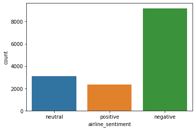

```python
# Let's make a basaic bar plot of counts by airline sentiment.
sns.countplot(x ='airline_sentiment', data = data)
# Show the plot
plt.show()
```

```
airline_sentiment  negative  neutral  positive    All
airline
All                    9178     3099      2363  14640
Southwest              1186      664       570   2420
Delta                   955      723       544   2222
United                 2633      697       492   3822
American               1960      463       336   2759
US Airways             2263      381       269   2913
Virgin America          181      171       152    504
------------------------------------------------------------------------------------------------------------------------
```

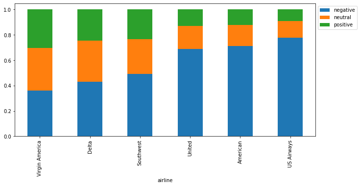

```python
# Now, let's look at the same distribution as stacked bars separately for each airline.
# These are height balanced bars, which makes it easy to make relative comparison among airlines.
stacked_barplot(data, "airline", "airline_sentiment")
```

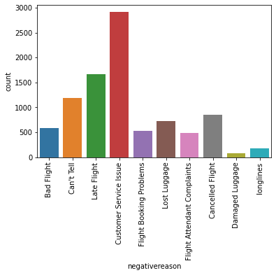

```python
# Let's make a basic bar plot of counts by airline sentiment for negative tweets.
s1 = sns.countplot(x ='negativereason', data = data[data['airline_sentiment'] == 'negative'])
s1.set_xticklabels(s1.get_xticklabels(),rotation=90)
# Show the plot
plt.show()
```

```
negativereason  Bad Flight  Can't Tell  Cancelled Flight  \
airline
All                    580        1190               847
United                 216         379               181
Southwest               90         159               162
American                87         198               246
Delta                   64         186                51
US Airways             104         246               189
Virgin America          19          22                18

negativereason  Customer Service Issue  Damaged Luggage  \
airline
All                               2910               74
United                             681               22
Southwest                          391               14
American                           768               12
Delta                              199               11
US Airways                         811               11
Virgin America                      60                4

negativereason  Flight Attendant Complaints  Flight Booking Problems  \
airline
All                                     481                      529
United                                  168                      144
Southwest                                38                       61
American                                 87                      130
Delta                                    60                       44
US Airways                              123                      122
Virgin America                            5                       28

negativereason  Late Flight  Lost Luggage  longlines   All
airline
All                    1665           724        178  9178
United                  525           269         48  2633
Southwest               152            90         29  1186
American                249           149         34  1960
Delta                   269            57         14   955
US Airways              453           154         50  2263
Virgin America           17             5          3   181
------------------------------------------------------------------------------------------------------------------------
```

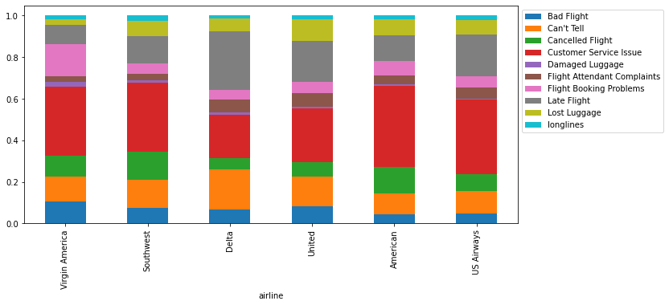

```python
# For the tweets marked negative, let's look at the distribution of reasons by each airline.
# Again, being height balanced bars, it is easy to compare across airlines..
stacked_barplot(data[data['airline_sentiment'] == 'negative'], "airline", "negativereason")
```

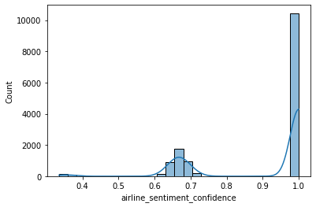

```python
# Let's look at a histogram of airline_sentiment_confidence.
sns.histplot(data = data, x = "airline_sentiment_confidence", kde = True);
```

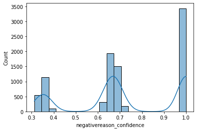

```python
# Let's look at a histogram of negativereason_confidence.
sns.histplot(data = data[data['airline_sentiment'] == 'negative'], x = "negativereason_confidence", kde = True);
```

- We have done some basic EDA so far. We need to do more work before creating word clouds.

### **Text Pre-processing:**

- Remove html tags.
- Replace contractions in string. (e.g. replace I'm --> I am) and so on.
- Remove numbers.
- Make text lowercase.
- Tokenization
- To remove Stopwords.
- Lemmatize text.

We will use the **NLTK library to tokenize words, remove stopwords and lemmatize the remaining words**

```python
pd.set_option('display.max_colwidth', None) # Display full dataframe information (Non-turncated Text column.)

data.head()                                 # Check first 5 rows of data
```

|  | tweet_id | airline_sentiment | airline_sentiment_confidence | negativereason | negativereason_confidence | airline | airline_sentiment_gold | name | negativereason_gold | retweet_count | text | tweet_coord | tweet_created | tweet_location | user_timezone |
| --- | --- | --- | --- | --- | --- | --- | --- | --- | --- | --- | --- | --- | --- | --- | --- |
| 0 | 570306133677760513 | neutral | 1.0000 | NaN | NaN | Virgin America | NaN | cairdin | NaN | 0 | @VirginAmerica What @dhepburn said. | NaN | 2015-02-24 11:35:52 -0800 | NaN | Eastern Time (US & Canada) |
| 1 | 570301130888122368 | positive | 0.3486 | NaN | 0.0000 | Virgin America | NaN | jnardino | NaN | 0 | @VirginAmerica plus you've added commercials to the experience... tacky. | NaN | 2015-02-24 11:15:59 -0800 | NaN | Pacific Time (US & Canada) |
| 2 | 570301083672813571 | neutral | 0.6837 | NaN | NaN | Virgin America | NaN | yvonnalynn | NaN | 0 | @VirginAmerica I didn't today... Must mean I need to take another trip! | NaN | 2015-02-24 11:15:48 -0800 | Lets Play | Central Time (US & Canada) |
| 3 | 570301031407624196 | negative | 1.0000 | Bad Flight | 0.7033 | Virgin America | NaN | jnardino | NaN | 0 | @VirginAmerica it's really aggressive to blast obnoxious "entertainment" in your guests' faces &amp; they have little recourse | NaN | 2015-02-24 11:15:36 -0800 | NaN | Pacific Time (US & Canada) |
| 4 | 570300817074462722 | negative | 1.0000 | Can't Tell | 1.0000 | Virgin America | NaN | jnardino | NaN | 0 | @VirginAmerica and it's a really big bad thing about it | NaN | 2015-02-24 11:14:45 -0800 | NaN | Pacific Time (US & Canada) |

```python
def strip_html(text):
    """Utility function to remove html tags from text"""
    soup = BeautifulSoup(text, "html.parser")
    return soup.get_text()

# remove html tags from text using the above defined function.
data['text'] = data['text'].apply(lambda x: strip_html(x))

data.head()
```

|  | tweet_id | airline_sentiment | airline_sentiment_confidence | negativereason | negativereason_confidence | airline | airline_sentiment_gold | name | negativereason_gold | retweet_count | text | tweet_coord | tweet_created | tweet_location | user_timezone |
| --- | --- | --- | --- | --- | --- | --- | --- | --- | --- | --- | --- | --- | --- | --- | --- |
| 0 | 570306133677760513 | neutral | 1.0000 | NaN | NaN | Virgin America | NaN | cairdin | NaN | 0 | @VirginAmerica What @dhepburn said. | NaN | 2015-02-24 11:35:52 -0800 | NaN | Eastern Time (US & Canada) |
| 1 | 570301130888122368 | positive | 0.3486 | NaN | 0.0000 | Virgin America | NaN | jnardino | NaN | 0 | @VirginAmerica plus you've added commercials to the experience... tacky. | NaN | 2015-02-24 11:15:59 -0800 | NaN | Pacific Time (US & Canada) |
| 2 | 570301083672813571 | neutral | 0.6837 | NaN | NaN | Virgin America | NaN | yvonnalynn | NaN | 0 | @VirginAmerica I didn't today... Must mean I need to take another trip! | NaN | 2015-02-24 11:15:48 -0800 | Lets Play | Central Time (US & Canada) |
| 3 | 570301031407624196 | negative | 1.0000 | Bad Flight | 0.7033 | Virgin America | NaN | jnardino | NaN | 0 | @VirginAmerica it's really aggressive to blast obnoxious "entertainment" in your guests' faces & they have little recourse | NaN | 2015-02-24 11:15:36 -0800 | NaN | Pacific Time (US & Canada) |
| 4 | 570300817074462722 | negative | 1.0000 | Can't Tell | 1.0000 | Virgin America | NaN | jnardino | NaN | 0 | @VirginAmerica and it's a really big bad thing about it | NaN | 2015-02-24 11:14:45 -0800 | NaN | Pacific Time (US & Canada) |

```python
def replace_contractions(text):
    """Replace contractions in string of text"""
    return contractions.fix(text)

# remove all contractions from text using the above defined function.
data['text'] = data['text'].apply(lambda x: replace_contractions(x))

data.head()
```

|  | tweet_id | airline_sentiment | airline_sentiment_confidence | negativereason | negativereason_confidence | airline | airline_sentiment_gold | name | negativereason_gold | retweet_count | text | tweet_coord | tweet_created | tweet_location | user_timezone |
| --- | --- | --- | --- | --- | --- | --- | --- | --- | --- | --- | --- | --- | --- | --- | --- |
| 0 | 570306133677760513 | neutral | 1.0000 | NaN | NaN | Virgin America | NaN | cairdin | NaN | 0 | @VirginAmerica What @dhepburn said. | NaN | 2015-02-24 11:35:52 -0800 | NaN | Eastern Time (US & Canada) |
| 1 | 570301130888122368 | positive | 0.3486 | NaN | 0.0000 | Virgin America | NaN | jnardino | NaN | 0 | @VirginAmerica plus you have added commercials to the experience... tacky. | NaN | 2015-02-24 11:15:59 -0800 | NaN | Pacific Time (US & Canada) |
| 2 | 570301083672813571 | neutral | 0.6837 | NaN | NaN | Virgin America | NaN | yvonnalynn | NaN | 0 | @VirginAmerica I did not today... Must mean I need to take another trip! | NaN | 2015-02-24 11:15:48 -0800 | Lets Play | Central Time (US & Canada) |
| 3 | 570301031407624196 | negative | 1.0000 | Bad Flight | 0.7033 | Virgin America | NaN | jnardino | NaN | 0 | @VirginAmerica it is really aggressive to blast obnoxious "entertainment" in your guests' faces & they have little recourse | NaN | 2015-02-24 11:15:36 -0800 | NaN | Pacific Time (US & Canada) |
| 4 | 570300817074462722 | negative | 1.0000 | Can't Tell | 1.0000 | Virgin America | NaN | jnardino | NaN | 0 | @VirginAmerica and it is a really big bad thing about it | NaN | 2015-02-24 11:14:45 -0800 | NaN | Pacific Time (US & Canada) |

```python
# Before we remove numbers from the tweet, let's take a look at them.
data.loc[data["text"].str.contains("\d+")].head()
```

|  | tweet_id | airline_sentiment | airline_sentiment_confidence | negativereason | negativereason_confidence | airline | airline_sentiment_gold | name | negativereason_gold | retweet_count | text | tweet_coord | tweet_created | tweet_location | user_timezone |
| --- | --- | --- | --- | --- | --- | --- | --- | --- | --- | --- | --- | --- | --- | --- | --- |
| 5 | 570300767074181121 | negative | 1.0000 | Can't Tell | 0.6842 | Virgin America | NaN | jnardino | NaN | 0 | @VirginAmerica seriously would pay $30 a flight for seats that did not have this playing.\nit is really the only bad thing about flying VA | NaN | 2015-02-24 11:14:33 -0800 | NaN | Pacific Time (US & Canada) |
| 7 | 570300248553349120 | neutral | 0.6340 | NaN | NaN | Virgin America | NaN | pilot | NaN | 0 | @VirginAmerica Really missed a prime opportunity for Men Without Hats parody, there. https://t.co/mWpG7grEZP | NaN | 2015-02-24 11:12:29 -0800 | Los Angeles | Pacific Time (US & Canada) |
| 10 | 570294189143031808 | neutral | 0.6769 | NaN | 0.0000 | Virgin America | NaN | idk_but_youtube | NaN | 0 | @VirginAmerica did you know that suicide is the second leading because of death among teens 10-24 | NaN | 2015-02-24 10:48:24 -0800 | 1/1 loner squad | Eastern Time (US & Canada) |
| 11 | 570289724453216256 | positive | 1.0000 | NaN | NaN | Virgin America | NaN | HyperCamiLax | NaN | 0 | @VirginAmerica I <3 pretty graphics. so much better than minimal iconography. :D | NaN | 2015-02-24 10:30:40 -0800 | NYC | America/New_York |
| 12 | 570289584061480960 | positive | 1.0000 | NaN | NaN | Virgin America | NaN | HyperCamiLax | NaN | 0 | @VirginAmerica This is such a great deal! Already thinking about my 2nd trip to @Australia & I have not even gone on my 1st trip yet! ;p | NaN | 2015-02-24 10:30:06 -0800 | NYC | America/New_York |

```python
# How many tweets have some number in the text field
data.loc[data["text"].str.contains("\d+")].shape
```

```
(5864, 15)
```

```python
def remove_numbers(text):
  """remove numbers from text"""
  text = re.sub(r'\d+', '', text)
  return text

# use above defined function to remove numerics from text
data['text'] = data['text'].apply(lambda x: remove_numbers(x))

data.head()
```

|  | tweet_id | airline_sentiment | airline_sentiment_confidence | negativereason | negativereason_confidence | airline | airline_sentiment_gold | name | negativereason_gold | retweet_count | text | tweet_coord | tweet_created | tweet_location | user_timezone |
| --- | --- | --- | --- | --- | --- | --- | --- | --- | --- | --- | --- | --- | --- | --- | --- |
| 0 | 570306133677760513 | neutral | 1.0000 | NaN | NaN | Virgin America | NaN | cairdin | NaN | 0 | @VirginAmerica What @dhepburn said. | NaN | 2015-02-24 11:35:52 -0800 | NaN | Eastern Time (US & Canada) |
| 1 | 570301130888122368 | positive | 0.3486 | NaN | 0.0000 | Virgin America | NaN | jnardino | NaN | 0 | @VirginAmerica plus you have added commercials to the experience... tacky. | NaN | 2015-02-24 11:15:59 -0800 | NaN | Pacific Time (US & Canada) |
| 2 | 570301083672813571 | neutral | 0.6837 | NaN | NaN | Virgin America | NaN | yvonnalynn | NaN | 0 | @VirginAmerica I did not today... Must mean I need to take another trip! | NaN | 2015-02-24 11:15:48 -0800 | Lets Play | Central Time (US & Canada) |
| 3 | 570301031407624196 | negative | 1.0000 | Bad Flight | 0.7033 | Virgin America | NaN | jnardino | NaN | 0 | @VirginAmerica it is really aggressive to blast obnoxious "entertainment" in your guests' faces & they have little recourse | NaN | 2015-02-24 11:15:36 -0800 | NaN | Pacific Time (US & Canada) |
| 4 | 570300817074462722 | negative | 1.0000 | Can't Tell | 1.0000 | Virgin America | NaN | jnardino | NaN | 0 | @VirginAmerica and it is a really big bad thing about it | NaN | 2015-02-24 11:14:45 -0800 | NaN | Pacific Time (US & Canada) |

```python
# Now that we have removed numbers from the tweet, this should return no rows.
data.loc[data["text"].str.contains("\d+")].head()
```

|  | tweet_id | airline_sentiment | airline_sentiment_confidence | negativereason | negativereason_confidence | airline | airline_sentiment_gold | name | negativereason_gold | retweet_count | text | tweet_coord | tweet_created | tweet_location | user_timezone |
| --- | --- | --- | --- | --- | --- | --- | --- | --- | --- | --- | --- | --- | --- | --- | --- |

- Since the above code returned no rows, we know the code to remove numbers from tweet text worked!

```python
# We use the NLTK library to tokenize the data
data['text'] = data.apply(lambda row: nltk.word_tokenize(row['text']), axis=1) # Tokenization of data
data.head()
```

|  | tweet_id | airline_sentiment | airline_sentiment_confidence | negativereason | negativereason_confidence | airline | airline_sentiment_gold | name | negativereason_gold | retweet_count | text | tweet_coord | tweet_created | tweet_location | user_timezone |
| --- | --- | --- | --- | --- | --- | --- | --- | --- | --- | --- | --- | --- | --- | --- | --- |
| 0 | 570306133677760513 | neutral | 1.0000 | NaN | NaN | Virgin America | NaN | cairdin | NaN | 0 | [@, VirginAmerica, What, @, dhepburn, said, .] | NaN | 2015-02-24 11:35:52 -0800 | NaN | Eastern Time (US & Canada) |
| 1 | 570301130888122368 | positive | 0.3486 | NaN | 0.0000 | Virgin America | NaN | jnardino | NaN | 0 | [@, VirginAmerica, plus, you, have, added, commercials, to, the, experience, ..., tacky, .] | NaN | 2015-02-24 11:15:59 -0800 | NaN | Pacific Time (US & Canada) |
| 2 | 570301083672813571 | neutral | 0.6837 | NaN | NaN | Virgin America | NaN | yvonnalynn | NaN | 0 | [@, VirginAmerica, I, did, not, today, ..., Must, mean, I, need, to, take, another, trip, !] | NaN | 2015-02-24 11:15:48 -0800 | Lets Play | Central Time (US & Canada) |
| 3 | 570301031407624196 | negative | 1.0000 | Bad Flight | 0.7033 | Virgin America | NaN | jnardino | NaN | 0 | [@, VirginAmerica, it, is, really, aggressive, to, blast, obnoxious, ``, entertainment, '', in, your, guests, ', faces, &, they, have, little, recourse] | NaN | 2015-02-24 11:15:36 -0800 | NaN | Pacific Time (US & Canada) |
| 4 | 570300817074462722 | negative | 1.0000 | Can't Tell | 1.0000 | Virgin America | NaN | jnardino | NaN | 0 | [@, VirginAmerica, and, it, is, a, really, big, bad, thing, about, it] | NaN | 2015-02-24 11:14:45 -0800 | NaN | Pacific Time (US & Canada) |

```python
# Let's get the standard stop words
stopwords = stopwords.words('english')

# Since airline names are likely come up a lot in tweets, let's have a way to consider them stop words.
airwaysnames = ['usairways','jetblue','flight','unite','americanair','southwestair','http','virginamerica']
# Combine the lists (while removing duplicates)
z = list(set(stopwords).union(set(airwaysnames)))

# Set custom stop-word's list as not, couldn't etc. words matter in Sentiment, so not removing them from original data.
customlist = ['not', "couldn't", 'didn', "didn't", 'doesn', "doesn't", 'hadn', "hadn't", 'hasn',
        "hasn't", 'haven', "haven't", 'isn', "isn't", 'ma', 'mightn', "mightn't", 'mustn',
        "mustn't", 'needn', "needn't", 'shan', "shan't", 'shouldn', "shouldn't", 'wasn',
        "wasn't", 'weren', "weren't", 'won', "won't", 'wouldn', "wouldn't"]
stopwords = list(set(z) - set(customlist))
```

```python
# define utility clean up functions

lemmatizer = WordNetLemmatizer()

def remove_non_ascii(words):
    """Remove non-ASCII characters from list of tokenized words"""
    new_words = []
    for word in words:
        new_word = unicodedata.normalize('NFKD', word).encode('ascii', 'ignore').decode('utf-8', 'ignore')
        new_words.append(new_word)
    return new_words

def to_lowercase(words):
    """Convert all characters to lowercase from list of tokenized words"""
    new_words = []
    for word in words:
        new_word = word.lower()
        new_words.append(new_word)
    return new_words

def remove_punctuation(words):
    """Remove punctuation from list of tokenized words"""
    new_words = []
    for word in words:
        new_word = re.sub(r'[^\w\s]', '', word)
        if new_word != '':
            new_words.append(new_word)
    return new_words

def remove_stopwords(words):
    """Remove stop words from list of tokenized words"""
    new_words = []
    for word in words:
        if word not in stopwords:
            new_words.append(word)
    return new_words

def lemmatize_list(words):
    new_words = []
    for word in words:
      new_words.append(lemmatizer.lemmatize(word, pos='v'))
    return new_words

def normalize(words):
    words = remove_non_ascii(words)
    words = to_lowercase(words)
    words = remove_punctuation(words)
    words = remove_stopwords(words)
    words = lemmatize_list(words)
    return ' '.join(words)
```

```python
# Call the normalize function defined above which in turn calls other clean up functions.
nltk.download('omw-1.4')
data['text'] = data.apply(lambda row: normalize(row['text']), axis=1)
data.head() # Let's look at a few rows after pre-processing.
```

|  | tweet_id | airline_sentiment | airline_sentiment_confidence | negativereason | negativereason_confidence | airline | airline_sentiment_gold | name | negativereason_gold | retweet_count | text | tweet_coord | tweet_created | tweet_location | user_timezone |
| --- | --- | --- | --- | --- | --- | --- | --- | --- | --- | --- | --- | --- | --- | --- | --- |
| 0 | 570306133677760513 | neutral | 1.0000 | NaN | NaN | Virgin America | NaN | cairdin | NaN | 0 | dhepburn say | NaN | 2015-02-24 11:35:52 -0800 | NaN | Eastern Time (US & Canada) |
| 1 | 570301130888122368 | positive | 0.3486 | NaN | 0.0000 | Virgin America | NaN | jnardino | NaN | 0 | plus add commercials experience tacky | NaN | 2015-02-24 11:15:59 -0800 | NaN | Pacific Time (US & Canada) |
| 2 | 570301083672813571 | neutral | 0.6837 | NaN | NaN | Virgin America | NaN | yvonnalynn | NaN | 0 | not today must mean need take another trip | NaN | 2015-02-24 11:15:48 -0800 | Lets Play | Central Time (US & Canada) |
| 3 | 570301031407624196 | negative | 1.0000 | Bad Flight | 0.7033 | Virgin America | NaN | jnardino | NaN | 0 | really aggressive blast obnoxious entertainment guests face little recourse | NaN | 2015-02-24 11:15:36 -0800 | NaN | Pacific Time (US & Canada) |
| 4 | 570300817074462722 | negative | 1.0000 | Can't Tell | 1.0000 | Virgin America | NaN | jnardino | NaN | 0 | really big bad thing | NaN | 2015-02-24 11:14:45 -0800 | NaN | Pacific Time (US & Canada) |

- Now that the text has been cleaned, we can do word clouds.

```python
def show_wordcloud(data, colname, title):
    """Show a word cloud using the WordCloud library"""
    text = ' '.join(data[colname].astype(str).tolist())                 # Converting Summary column into list
    stopwords = set(wordcloud.STOPWORDS)                                  # instantiate the stopwords from wordcloud

    fig_wordcloud = wordcloud.WordCloud(stopwords=stopwords,background_color='white',          # Setting the different parameter of stopwords
                    colormap='viridis', width=800, height=600).generate(text)

    plt.figure(figsize=(14,11), frameon=True)
    plt.imshow(fig_wordcloud)
    plt.axis('off')
    plt.title(title, fontsize=30)
    plt.show()
```

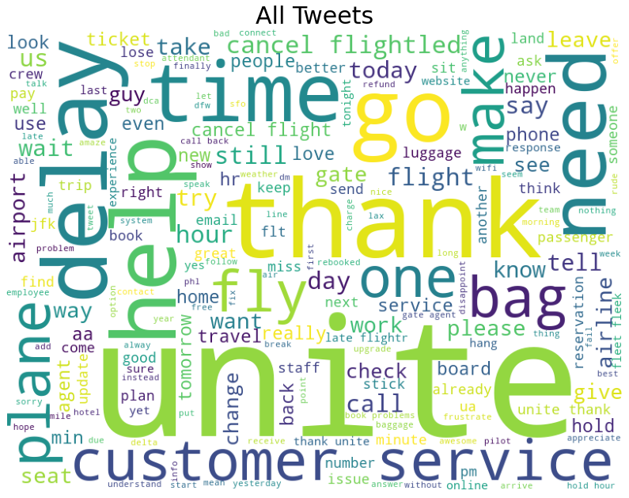

```python
show_wordcloud(data,'text','All Tweets')
```

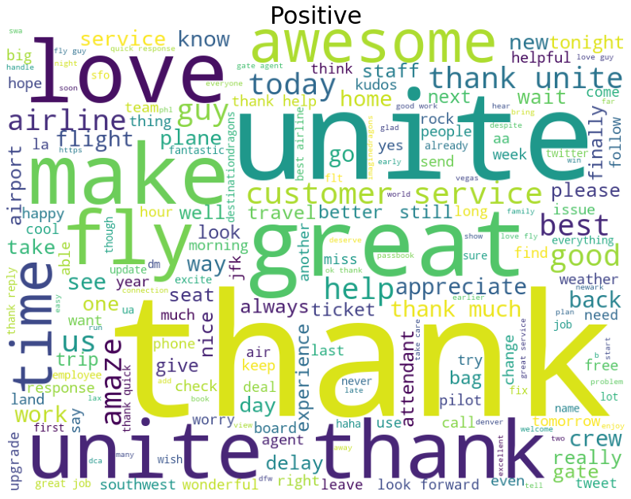

```python
# Show word cloud for positive tweets only.
show_wordcloud(data[data.airline_sentiment == 'positive'],'text', title = "Positive")
```

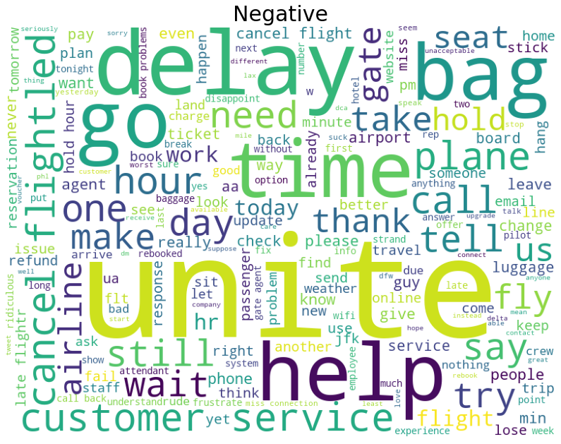

```python
# Show word cloud for negative tweets only.
show_wordcloud(data[data.airline_sentiment == 'negative'],'text', title = "Negative")
```

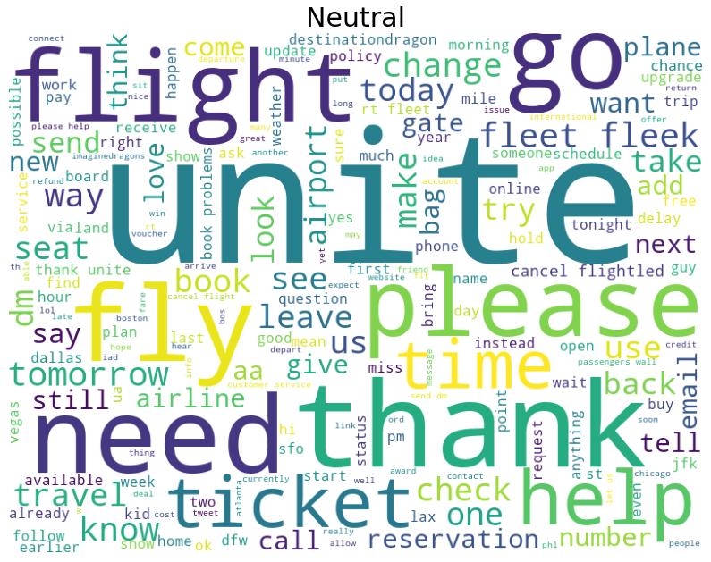

```python
show_wordcloud(data[data.airline_sentiment == 'neutral'],'text', title = "Neutral")
```

### **Observations from the EDA**:

- There are 15 columns and about 15K rows.
- `tweet_id` is the ID column and will play no role in modeling. `text` is the main field of interest as it contains the tweet content that will be used for NLP. `airline_sentiment` has the sentiment associated with the tweet. `negativereason` column has the reason for the negative sentiment and is available for tweets categorized as negative.
- There are many blanks in many columns but none of them needs to be addressed as we don't use them in this analysis. Note that `negativereason` is blank for tweets that are neutral or positive. This is okay.
- More than three fifth of tweets are categorized as negative. About a fifth are neutral. The rest are positive.
- Among negative tweets, about a third are negative due to customer service issues. A fifth are related to delays.
- More than a quarter of the tweets are about United airline. US Airways and American Airlines take up a fifth each. Virgin America has the least representation at 3.4%
- Among the US timezones, Eastern time zone has the highest count followed by Central and Pacific respectively.
- Virgin America has the least number of tweets, but has the biggest percentage positive tweets. Among the worst airlines, going by percentage positive tweets, are US Airways, American Airlines and United.
- Looking at the negative tweet reason, Delta and United stand out, as their percentage of negative tweets that are about customer service issues, is not as high as the others. Delta seems to have a large percentage of tweets about late flights. United seems to be the worst as far as lost luggage is concerned.
- Almost two third tweets have a 1.0 confidence on the sentiment value. Only about 37% of negative tweets have a reason confidence score of 1.0.
- More than a third of all tweets have one or more numbers in the text.
- Common words in the positive tweets are: thank, love, best, good, great, well. Common words in the negative tweets are: delay, bag, wait, call, time, customer service, gate, hold, baggage, seat, fix, rebooked, frustrate, cancel. The juxtaposition between the two categories is clear. Positive tweets are associated with good/warm/thankful feelings and the negative tweets are well, negative. The biggest issues that the negative tweets seem to be about are - delays and poor customer service.

### **Model Building**

```python
# The text column is the one that we will use for the next phases.
# Note that other columns are not being explicitly dropped. However, they are ignored here onwards.
data['text'].head()
```

```
0                                                                   dhepburn say
1                                          plus add commercials experience tacky
2                                     not today must mean need take another trip
3    really aggressive blast obnoxious entertainment guests face little recourse
4                                                           really big bad thing
Name: text, dtype: object
```

- Let's start with a simple sentiment analysis using Vader.

```python
#download vader lexicon
nltk.download('vader_lexicon')

sentiment = SentimentIntensityAnalyzer() # sentiment object
```

```python
data_new = data.copy()   #make a copy of dataframe and do unsupervised operations on that dataframe
```

```python
#Calculate the polarity score of the reviews
data_new['scores'] = data_new['text'].apply(lambda review: sentiment.polarity_scores(review))

data_new.head()
```

|  | tweet_id | airline_sentiment | airline_sentiment_confidence | negativereason | negativereason_confidence | airline | airline_sentiment_gold | name | negativereason_gold | retweet_count | text | tweet_coord | tweet_created | tweet_location | user_timezone | scores |
| --- | --- | --- | --- | --- | --- | --- | --- | --- | --- | --- | --- | --- | --- | --- | --- | --- |
| 0 | 570306133677760513 | neutral | 1.0000 | NaN | NaN | Virgin America | NaN | cairdin | NaN | 0 | dhepburn say | NaN | 2015-02-24 11:35:52 -0800 | NaN | Eastern Time (US & Canada) | {'neg': 0.0, 'neu': 1.0, 'pos': 0.0, 'compound': 0.0} |
| 1 | 570301130888122368 | positive | 0.3486 | NaN | 0.0000 | Virgin America | NaN | jnardino | NaN | 0 | plus add commercials experience tacky | NaN | 2015-02-24 11:15:59 -0800 | NaN | Pacific Time (US & Canada) | {'neg': 0.0, 'neu': 1.0, 'pos': 0.0, 'compound': 0.0} |
| 2 | 570301083672813571 | neutral | 0.6837 | NaN | NaN | Virgin America | NaN | yvonnalynn | NaN | 0 | not today must mean need take another trip | NaN | 2015-02-24 11:15:48 -0800 | Lets Play | Central Time (US & Canada) | {'neg': 0.0, 'neu': 1.0, 'pos': 0.0, 'compound': 0.0} |
| 3 | 570301031407624196 | negative | 1.0000 | Bad Flight | 0.7033 | Virgin America | NaN | jnardino | NaN | 0 | really aggressive blast obnoxious entertainment guests face little recourse | NaN | 2015-02-24 11:15:36 -0800 | NaN | Pacific Time (US & Canada) | {'neg': 0.369, 'neu': 0.43, 'pos': 0.201, 'compound': -0.3306} |
| 4 | 570300817074462722 | negative | 1.0000 | Can't Tell | 1.0000 | Virgin America | NaN | jnardino | NaN | 0 | really big bad thing | NaN | 2015-02-24 11:14:45 -0800 | NaN | Pacific Time (US & Canada) | {'neg': 0.557, 'neu': 0.443, 'pos': 0.0, 'compound': -0.5829} |

```python
#Calculate the compund score of the reviews
data_new['compound']  = data_new['scores'].apply(lambda score_dict: score_dict['compound'])

data_new.head()
```

|  | tweet_id | airline_sentiment | airline_sentiment_confidence | negativereason | negativereason_confidence | airline | airline_sentiment_gold | name | negativereason_gold | retweet_count | text | tweet_coord | tweet_created | tweet_location | user_timezone | scores | compound |
| --- | --- | --- | --- | --- | --- | --- | --- | --- | --- | --- | --- | --- | --- | --- | --- | --- | --- |
| 0 | 570306133677760513 | neutral | 1.0000 | NaN | NaN | Virgin America | NaN | cairdin | NaN | 0 | dhepburn say | NaN | 2015-02-24 11:35:52 -0800 | NaN | Eastern Time (US & Canada) | {'neg': 0.0, 'neu': 1.0, 'pos': 0.0, 'compound': 0.0} | 0.0000 |
| 1 | 570301130888122368 | positive | 0.3486 | NaN | 0.0000 | Virgin America | NaN | jnardino | NaN | 0 | plus add commercials experience tacky | NaN | 2015-02-24 11:15:59 -0800 | NaN | Pacific Time (US & Canada) | {'neg': 0.0, 'neu': 1.0, 'pos': 0.0, 'compound': 0.0} | 0.0000 |
| 2 | 570301083672813571 | neutral | 0.6837 | NaN | NaN | Virgin America | NaN | yvonnalynn | NaN | 0 | not today must mean need take another trip | NaN | 2015-02-24 11:15:48 -0800 | Lets Play | Central Time (US & Canada) | {'neg': 0.0, 'neu': 1.0, 'pos': 0.0, 'compound': 0.0} | 0.0000 |
| 3 | 570301031407624196 | negative | 1.0000 | Bad Flight | 0.7033 | Virgin America | NaN | jnardino | NaN | 0 | really aggressive blast obnoxious entertainment guests face little recourse | NaN | 2015-02-24 11:15:36 -0800 | NaN | Pacific Time (US & Canada) | {'neg': 0.369, 'neu': 0.43, 'pos': 0.201, 'compound': -0.3306} | -0.3306 |
| 4 | 570300817074462722 | negative | 1.0000 | Can't Tell | 1.0000 | Virgin America | NaN | jnardino | NaN | 0 | really big bad thing | NaN | 2015-02-24 11:14:45 -0800 | NaN | Pacific Time (US & Canada) | {'neg': 0.557, 'neu': 0.443, 'pos': 0.0, 'compound': -0.5829} | -0.5829 |

```python
#Classify the class of the review by keeping threshold on the compund score
data_new['comp_score'] = data_new['compound'].apply(lambda c: '1' if c >=0 else '0')

data_new.head()
```

|  | tweet_id | airline_sentiment | airline_sentiment_confidence | negativereason | negativereason_confidence | airline | airline_sentiment_gold | name | negativereason_gold | retweet_count | text | tweet_coord | tweet_created | tweet_location | user_timezone | scores | compound | comp_score |
| --- | --- | --- | --- | --- | --- | --- | --- | --- | --- | --- | --- | --- | --- | --- | --- | --- | --- | --- |
| 0 | 570306133677760513 | neutral | 1.0000 | NaN | NaN | Virgin America | NaN | cairdin | NaN | 0 | dhepburn say | NaN | 2015-02-24 11:35:52 -0800 | NaN | Eastern Time (US & Canada) | {'neg': 0.0, 'neu': 1.0, 'pos': 0.0, 'compound': 0.0} | 0.0000 | 1 |
| 1 | 570301130888122368 | positive | 0.3486 | NaN | 0.0000 | Virgin America | NaN | jnardino | NaN | 0 | plus add commercials experience tacky | NaN | 2015-02-24 11:15:59 -0800 | NaN | Pacific Time (US & Canada) | {'neg': 0.0, 'neu': 1.0, 'pos': 0.0, 'compound': 0.0} | 0.0000 | 1 |
| 2 | 570301083672813571 | neutral | 0.6837 | NaN | NaN | Virgin America | NaN | yvonnalynn | NaN | 0 | not today must mean need take another trip | NaN | 2015-02-24 11:15:48 -0800 | Lets Play | Central Time (US & Canada) | {'neg': 0.0, 'neu': 1.0, 'pos': 0.0, 'compound': 0.0} | 0.0000 | 1 |
| 3 | 570301031407624196 | negative | 1.0000 | Bad Flight | 0.7033 | Virgin America | NaN | jnardino | NaN | 0 | really aggressive blast obnoxious entertainment guests face little recourse | NaN | 2015-02-24 11:15:36 -0800 | NaN | Pacific Time (US & Canada) | {'neg': 0.369, 'neu': 0.43, 'pos': 0.201, 'compound': -0.3306} | -0.3306 | 0 |
| 4 | 570300817074462722 | negative | 1.0000 | Can't Tell | 1.0000 | Virgin America | NaN | jnardino | NaN | 0 | really big bad thing | NaN | 2015-02-24 11:14:45 -0800 | NaN | Pacific Time (US & Canada) | {'neg': 0.557, 'neu': 0.443, 'pos': 0.0, 'compound': -0.5829} | -0.5829 | 0 |

```python
data_new['comp_score'].value_counts(dropna=False) # Let's look at a break up of the sentiment
```

```
1    9812
0    4828
Name: comp_score, dtype: int64
```

```python
data["VADER_pred"] = data_new['comp_score'].tolist() # Let's copy the vader sentiment into the main dataframe
data.head()
```

|  | tweet_id | airline_sentiment | airline_sentiment_confidence | negativereason | negativereason_confidence | airline | airline_sentiment_gold | name | negativereason_gold | retweet_count | text | tweet_coord | tweet_created | tweet_location | user_timezone | VADER_pred |
| --- | --- | --- | --- | --- | --- | --- | --- | --- | --- | --- | --- | --- | --- | --- | --- | --- |
| 0 | 570306133677760513 | neutral | 1.0000 | NaN | NaN | Virgin America | NaN | cairdin | NaN | 0 | dhepburn say | NaN | 2015-02-24 11:35:52 -0800 | NaN | Eastern Time (US & Canada) | 1 |
| 1 | 570301130888122368 | positive | 0.3486 | NaN | 0.0000 | Virgin America | NaN | jnardino | NaN | 0 | plus add commercials experience tacky | NaN | 2015-02-24 11:15:59 -0800 | NaN | Pacific Time (US & Canada) | 1 |
| 2 | 570301083672813571 | neutral | 0.6837 | NaN | NaN | Virgin America | NaN | yvonnalynn | NaN | 0 | not today must mean need take another trip | NaN | 2015-02-24 11:15:48 -0800 | Lets Play | Central Time (US & Canada) | 1 |
| 3 | 570301031407624196 | negative | 1.0000 | Bad Flight | 0.7033 | Virgin America | NaN | jnardino | NaN | 0 | really aggressive blast obnoxious entertainment guests face little recourse | NaN | 2015-02-24 11:15:36 -0800 | NaN | Pacific Time (US & Canada) | 0 |
| 4 | 570300817074462722 | negative | 1.0000 | Can't Tell | 1.0000 | Virgin America | NaN | jnardino | NaN | 0 | really big bad thing | NaN | 2015-02-24 11:14:45 -0800 | NaN | Pacific Time (US & Canada) | 0 |

```python
#Classify the class of the review by keeping threshold on the compund score. To keep things consistent, we treat the neutral as "1".
data['given_score'] = data['airline_sentiment'].apply(lambda c: '0' if c =='negative' else '1')

data.head()
```

|  | tweet_id | airline_sentiment | airline_sentiment_confidence | negativereason | negativereason_confidence | airline | airline_sentiment_gold | name | negativereason_gold | retweet_count | text | tweet_coord | tweet_created | tweet_location | user_timezone | VADER_pred | given_score |
| --- | --- | --- | --- | --- | --- | --- | --- | --- | --- | --- | --- | --- | --- | --- | --- | --- | --- |
| 0 | 570306133677760513 | neutral | 1.0000 | NaN | NaN | Virgin America | NaN | cairdin | NaN | 0 | dhepburn say | NaN | 2015-02-24 11:35:52 -0800 | NaN | Eastern Time (US & Canada) | 1 | 1 |
| 1 | 570301130888122368 | positive | 0.3486 | NaN | 0.0000 | Virgin America | NaN | jnardino | NaN | 0 | plus add commercials experience tacky | NaN | 2015-02-24 11:15:59 -0800 | NaN | Pacific Time (US & Canada) | 1 | 1 |
| 2 | 570301083672813571 | neutral | 0.6837 | NaN | NaN | Virgin America | NaN | yvonnalynn | NaN | 0 | not today must mean need take another trip | NaN | 2015-02-24 11:15:48 -0800 | Lets Play | Central Time (US & Canada) | 1 | 1 |
| 3 | 570301031407624196 | negative | 1.0000 | Bad Flight | 0.7033 | Virgin America | NaN | jnardino | NaN | 0 | really aggressive blast obnoxious entertainment guests face little recourse | NaN | 2015-02-24 11:15:36 -0800 | NaN | Pacific Time (US & Canada) | 0 | 0 |
| 4 | 570300817074462722 | negative | 1.0000 | Can't Tell | 1.0000 | Virgin America | NaN | jnardino | NaN | 0 | really big bad thing | NaN | 2015-02-24 11:14:45 -0800 | NaN | Pacific Time (US & Canada) | 0 | 0 |

```python
data[['VADER_pred','airline_sentiment','given_score']].value_counts(dropna=False) # Cross tabulation of the two sentiment flags
```

```
VADER_pred  airline_sentiment  given_score
1           negative           0              4888
0           negative           0              4290
1           neutral            1              2666
            positive           1              2258
0           neutral            1               433
            positive           1               105
dtype: int64
```

```python
data_pn = data[data['airline_sentiment'] != 'neutral']
data_pn[['VADER_pred','airline_sentiment','given_score']].value_counts(dropna=False) # Cross tabulation of the two sentiment flags ignoring the neutral tweets
```

```
VADER_pred  airline_sentiment  given_score
1           negative           0              4888
0           negative           0              4290
1           positive           1              2258
0           positive           1               105
dtype: int64
```

```python
#Calculate the accuracy of the Vader Sentiment Analysis

data["given_score"] = data["given_score"].astype(int)   #convert the sentiment column values into int data type
data["VADER_pred"] = data["VADER_pred"].astype(int) #convert the vader_predicted column values into int data type
print("Accuaracy using Vader Sentiment Analysis is : ",
      accuracy_score(data["given_score"].tolist(),data["VADER_pred"].tolist()))
```

```
Accuaracy using Vader Sentiment Analysis is :  0.6293715846994535
```

```python
#Calculate the accuracy of the Vader Sentiment Analysis ignoring the neutral tweets

data_pn["given_score"] = data_pn["given_score"].astype(int)   #convert the sentiment column values into int data type
data_pn["VADER_pred"] = data_pn["VADER_pred"].astype(int) #convert the vader_predicted column values into int data type
print("Accuaracy using Vader Sentiment Analysis is : ",
      accuracy_score(data_pn["given_score"].tolist(),data_pn["VADER_pred"].tolist()))
```

```
Accuaracy using Vader Sentiment Analysis is :  0.567368512260636
```

```
[[4290 4888]
 [ 538 4924]]
```

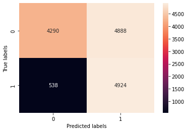

```python
# Print and plot Confusion matirx to get an idea of how the distribution of the prediction is, among all the classes.

conf_mat = confusion_matrix(data["given_score"].tolist(), data['VADER_pred'].tolist())
ax=plt.subplot()
print(conf_mat)

df_cm = pd.DataFrame(conf_mat, index = [i for i in ['0', '1']],
                  columns = [i for i in ['0', '1']])
plt.figure(figsize = (10,7))
sns.heatmap(df_cm, annot=True, fmt='g',ax=ax);
ax.set_xlabel('Predicted labels');ax.set_ylabel('True labels');
```

- Using **TextBlob**

```python
data_new = data.copy()      #make a copy of dataframe and do unsupervised operations on that dataframe
```

```python
#Calculate the polarity score of the reviews. This is using TextBlob library.
data_new['polarity']  = data_new['text'].apply(lambda review: TextBlob(review).sentiment.polarity)

data_new.head()
```

|  | tweet_id | airline_sentiment | airline_sentiment_confidence | negativereason | negativereason_confidence | airline | airline_sentiment_gold | name | negativereason_gold | retweet_count | text | tweet_coord | tweet_created | tweet_location | user_timezone | VADER_pred | given_score | polarity |
| --- | --- | --- | --- | --- | --- | --- | --- | --- | --- | --- | --- | --- | --- | --- | --- | --- | --- | --- |
| 0 | 570306133677760513 | neutral | 1.0000 | NaN | NaN | Virgin America | NaN | cairdin | NaN | 0 | dhepburn say | NaN | 2015-02-24 11:35:52 -0800 | NaN | Eastern Time (US & Canada) | 1 | 1 | 0.00000 |
| 1 | 570301130888122368 | positive | 0.3486 | NaN | 0.0000 | Virgin America | NaN | jnardino | NaN | 0 | plus add commercials experience tacky | NaN | 2015-02-24 11:15:59 -0800 | NaN | Pacific Time (US & Canada) | 1 | 1 | 0.00000 |
| 2 | 570301083672813571 | neutral | 0.6837 | NaN | NaN | Virgin America | NaN | yvonnalynn | NaN | 0 | not today must mean need take another trip | NaN | 2015-02-24 11:15:48 -0800 | Lets Play | Central Time (US & Canada) | 1 | 1 | -0.31250 |
| 3 | 570301031407624196 | negative | 1.0000 | Bad Flight | 0.7033 | Virgin America | NaN | jnardino | NaN | 0 | really aggressive blast obnoxious entertainment guests face little recourse | NaN | 2015-02-24 11:15:36 -0800 | NaN | Pacific Time (US & Canada) | 0 | 0 | 0.00625 |
| 4 | 570300817074462722 | negative | 1.0000 | Can't Tell | 1.0000 | Virgin America | NaN | jnardino | NaN | 0 | really big bad thing | NaN | 2015-02-24 11:14:45 -0800 | NaN | Pacific Time (US & Canada) | 0 | 0 | -0.35000 |

```python
#Classify the class of the review by keeping threshold on the polarity score
data_new['polarity_score'] = data_new['polarity'].apply(lambda c: '1' if c >=0 else '0')

data_new.head()
```

|  | tweet_id | airline_sentiment | airline_sentiment_confidence | negativereason | negativereason_confidence | airline | airline_sentiment_gold | name | negativereason_gold | retweet_count | text | tweet_coord | tweet_created | tweet_location | user_timezone | VADER_pred | given_score | polarity | polarity_score |
| --- | --- | --- | --- | --- | --- | --- | --- | --- | --- | --- | --- | --- | --- | --- | --- | --- | --- | --- | --- |
| 0 | 570306133677760513 | neutral | 1.0000 | NaN | NaN | Virgin America | NaN | cairdin | NaN | 0 | dhepburn say | NaN | 2015-02-24 11:35:52 -0800 | NaN | Eastern Time (US & Canada) | 1 | 1 | 0.00000 | 1 |
| 1 | 570301130888122368 | positive | 0.3486 | NaN | 0.0000 | Virgin America | NaN | jnardino | NaN | 0 | plus add commercials experience tacky | NaN | 2015-02-24 11:15:59 -0800 | NaN | Pacific Time (US & Canada) | 1 | 1 | 0.00000 | 1 |
| 2 | 570301083672813571 | neutral | 0.6837 | NaN | NaN | Virgin America | NaN | yvonnalynn | NaN | 0 | not today must mean need take another trip | NaN | 2015-02-24 11:15:48 -0800 | Lets Play | Central Time (US & Canada) | 1 | 1 | -0.31250 | 0 |
| 3 | 570301031407624196 | negative | 1.0000 | Bad Flight | 0.7033 | Virgin America | NaN | jnardino | NaN | 0 | really aggressive blast obnoxious entertainment guests face little recourse | NaN | 2015-02-24 11:15:36 -0800 | NaN | Pacific Time (US & Canada) | 0 | 0 | 0.00625 | 1 |
| 4 | 570300817074462722 | negative | 1.0000 | Can't Tell | 1.0000 | Virgin America | NaN | jnardino | NaN | 0 | really big bad thing | NaN | 2015-02-24 11:14:45 -0800 | NaN | Pacific Time (US & Canada) | 0 | 0 | -0.35000 | 0 |

```python
data["Text_Blob_pred"] = data_new['polarity_score'].tolist()
data.head()
```

|  | tweet_id | airline_sentiment | airline_sentiment_confidence | negativereason | negativereason_confidence | airline | airline_sentiment_gold | name | negativereason_gold | retweet_count | text | tweet_coord | tweet_created | tweet_location | user_timezone | VADER_pred | given_score | Text_Blob_pred |
| --- | --- | --- | --- | --- | --- | --- | --- | --- | --- | --- | --- | --- | --- | --- | --- | --- | --- | --- |
| 0 | 570306133677760513 | neutral | 1.0000 | NaN | NaN | Virgin America | NaN | cairdin | NaN | 0 | dhepburn say | NaN | 2015-02-24 11:35:52 -0800 | NaN | Eastern Time (US & Canada) | 1 | 1 | 1 |
| 1 | 570301130888122368 | positive | 0.3486 | NaN | 0.0000 | Virgin America | NaN | jnardino | NaN | 0 | plus add commercials experience tacky | NaN | 2015-02-24 11:15:59 -0800 | NaN | Pacific Time (US & Canada) | 1 | 1 | 1 |
| 2 | 570301083672813571 | neutral | 0.6837 | NaN | NaN | Virgin America | NaN | yvonnalynn | NaN | 0 | not today must mean need take another trip | NaN | 2015-02-24 11:15:48 -0800 | Lets Play | Central Time (US & Canada) | 1 | 1 | 0 |
| 3 | 570301031407624196 | negative | 1.0000 | Bad Flight | 0.7033 | Virgin America | NaN | jnardino | NaN | 0 | really aggressive blast obnoxious entertainment guests face little recourse | NaN | 2015-02-24 11:15:36 -0800 | NaN | Pacific Time (US & Canada) | 0 | 0 | 1 |
| 4 | 570300817074462722 | negative | 1.0000 | Can't Tell | 1.0000 | Virgin America | NaN | jnardino | NaN | 0 | really big bad thing | NaN | 2015-02-24 11:14:45 -0800 | NaN | Pacific Time (US & Canada) | 0 | 0 | 0 |

```python
#Calculate the accuracy of the Vader Sentiment Analysis
data["given_score"] = data["given_score"].astype(int)  #convert the sentiment column values into int data type
data["Text_Blob_pred"] = data["Text_Blob_pred"].astype(int)  #convert the textblob predicted column values into int data type
print("Accuaracy of using Text Blob Sentiment Analysis is : ",
      accuracy_score(data["given_score"].tolist(),data["Text_Blob_pred"].tolist()))
```

```
Accuaracy of using Text Blob Sentiment Analysis is :  0.5441939890710382
```

```
[[2889 6289]
 [ 384 5078]]
```

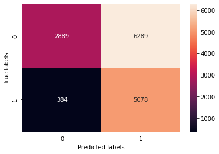

```python
# Print and plot Confusion matirx to get an idea of how the distribution of the prediction is, among all the classes.

conf_mat = confusion_matrix(data["given_score"].tolist(), data['Text_Blob_pred'].tolist())

print(conf_mat)
ax= plt.subplot();

df_cm = pd.DataFrame(conf_mat, index = [i for i in ['0', '1']],
                  columns = [i for i in ['0', '1']])
plt.figure(figsize = (10,7));
sns.heatmap(df_cm, annot=True, fmt='g', ax=ax);
ax.set_xlabel('Predicted labels');ax.set_ylabel('True labels');
```

- Having done relatively simpler things like Vader and TextBlob, let's move on to CountVectorizer and TfidfVectorizer.

```python
data.head()
```

|  | tweet_id | airline_sentiment | airline_sentiment_confidence | negativereason | negativereason_confidence | airline | airline_sentiment_gold | name | negativereason_gold | retweet_count | text | tweet_coord | tweet_created | tweet_location | user_timezone | VADER_pred | given_score | Text_Blob_pred |
| --- | --- | --- | --- | --- | --- | --- | --- | --- | --- | --- | --- | --- | --- | --- | --- | --- | --- | --- |
| 0 | 570306133677760513 | neutral | 1.0000 | NaN | NaN | Virgin America | NaN | cairdin | NaN | 0 | dhepburn say | NaN | 2015-02-24 11:35:52 -0800 | NaN | Eastern Time (US & Canada) | 1 | 1 | 1 |
| 1 | 570301130888122368 | positive | 0.3486 | NaN | 0.0000 | Virgin America | NaN | jnardino | NaN | 0 | plus add commercials experience tacky | NaN | 2015-02-24 11:15:59 -0800 | NaN | Pacific Time (US & Canada) | 1 | 1 | 1 |
| 2 | 570301083672813571 | neutral | 0.6837 | NaN | NaN | Virgin America | NaN | yvonnalynn | NaN | 0 | not today must mean need take another trip | NaN | 2015-02-24 11:15:48 -0800 | Lets Play | Central Time (US & Canada) | 1 | 1 | 0 |
| 3 | 570301031407624196 | negative | 1.0000 | Bad Flight | 0.7033 | Virgin America | NaN | jnardino | NaN | 0 | really aggressive blast obnoxious entertainment guests face little recourse | NaN | 2015-02-24 11:15:36 -0800 | NaN | Pacific Time (US & Canada) | 0 | 0 | 1 |
| 4 | 570300817074462722 | negative | 1.0000 | Can't Tell | 1.0000 | Virgin America | NaN | jnardino | NaN | 0 | really big bad thing | NaN | 2015-02-24 11:14:45 -0800 | NaN | Pacific Time (US & Canada) | 0 | 0 | 0 |

```python
# Vectorization (Convert text data to numbers).

bow_vec = CountVectorizer(max_features=2000)                # Keep only 2000 features as number of features will increase the processing time.
data_features = bow_vec.fit_transform(data['text'])

data_features = data_features.toarray()                        # Convert the data features to array.
```

```python
# Convert the sentiment to a numeric value.
data['Score'] = data['airline_sentiment'].apply(lambda c: '1' if c == 'positive' else ('0' if c == 'neutral' else '-1'))
```

```python
data[['airline_sentiment','Score']].value_counts(dropna=False) # Check the distribution
```

```
airline_sentiment  Score
negative           -1       9178
neutral            0        3099
positive           1        2363
dtype: int64
```

```python
labels = data['Score']
labels = labels.astype('int')
```

```python
# Split data into training and testing set.
X_train, X_test, y_train, y_test = train_test_split(data_features, labels, test_size=0.3, random_state=42)
```

```python
# Using Random Forest to build model for the classification of reviews.
# Also calculating the cross validation score.

forest = RandomForestClassifier(n_estimators=10, n_jobs=4)

forest = forest.fit(X_train, y_train)

print(forest)

print(np.mean(cross_val_score(forest, data_features, labels, cv=10)))
```

```
RandomForestClassifier(n_estimators=10, n_jobs=4)
0.7363387978142076
```

```python
# K-Fold Cross - validation
# "accuracy" is the chosen metric as it is the appropriate metric as we want to get both positive and negative classification right.
# f1 score would have been appropriate too.
cv_scores = []
base_ln = [x for x in range(1, 25)]
for b in base_ln:
    clf = RandomForestClassifier(n_estimators = b)
    scores = cross_val_score(clf, X_train, y_train, cv = 5, scoring = 'accuracy')
    cv_scores.append(scores.mean())
```

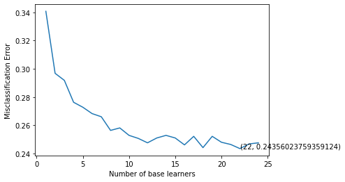

```python
# plotting the error as k increases
error = [1 - x for x in cv_scores]                                 #error corresponds to each nu of estimator
optimal_learners = base_ln[error.index(min(error))]                #Selection of optimal nu of n_estimator corresponds to minimum error.
plt.plot(base_ln, error)                                           #Plot between each nu of estimator and misclassification error
xy = (optimal_learners, min(error))
plt.annotate('(%s, %s)' % xy, xy = xy, textcoords='data')
plt.xlabel("Number of base learners")
plt.ylabel("Misclassification Error")
plt.show()
```

```python
# Training the best model and calculating accuracy on test data .
clf = RandomForestClassifier(n_estimators = optimal_learners)
clf.fit(X_train, y_train)
clf.score(X_test, y_test)
```

```
0.7775500910746812
```

```python
result =  clf.predict(X_test)                  #saving the prediction on test data as a result
```

```
[[2542  188   84]
 [ 366  433   85]
 [ 170   84  440]]
0.7775500910746813
```

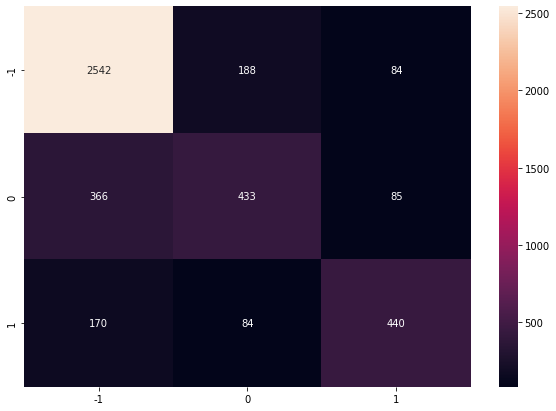

```python
# Print and plot Confusion matirx to get an idea of how the distribution of the prediction is, among all the classes.
conf_mat = confusion_matrix(y_test, result)

print(conf_mat)

print(metrics.f1_score(y_test, result,average='micro'))

df_cm = pd.DataFrame(conf_mat, index = [i for i in [-1,0,1]],
                  columns = [i for i in [-1,0,1]])
plt.figure(figsize = (10,7));
sns.heatmap(df_cm, annot=True, fmt='g');
```

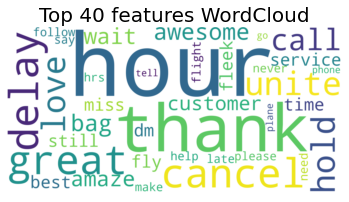

```python
all_features = bow_vec.get_feature_names()              #Instantiate the feature from the vectorizer
top_features=''                                            # Addition of top 40 feature into top_feature after training the model
feat=clf.feature_importances_
features=np.argsort(feat)[::-1]
for i in features[0:40]:
    top_features+=all_features[i]
    top_features+=' '

#from wordcloud import WordCloud
wordcloud = WordCloud(background_color="white",colormap='viridis',width=2000,
                          height=1000).generate(top_features);

# Display the generated image:
plt.imshow(wordcloud, interpolation='bilinear');
plt.figure(1, figsize=(14, 11), frameon='equal');
plt.title('Top 40 features WordCloud', fontsize=20)
plt.axis("off")
plt.show();
```

- Having done CountVectorizer, now we move to using TfidfVectorizer.

```python
# Using TfidfVectorizer to convert text data to numbers.

vectorizer = TfidfVectorizer(max_features=2000)
data_features = vectorizer.fit_transform(data['text'])

data_features = data_features.toarray()

data_features.shape
```

```
(14640, 2000)
```

```python
# Split data into training and testing set.
X_train, X_test, y_train, y_test = train_test_split(data_features, labels, test_size=0.3, random_state=42)
```

```python
# Using Random Forest to build model for the classification of reviews.
# Also calculating the cross validation score.

forest = RandomForestClassifier(n_estimators=10, n_jobs=4)

forest = forest.fit(X_train, y_train)

print(forest)

print(np.mean(cross_val_score(forest, data_features, labels, cv=5)))
```

```
RandomForestClassifier(n_estimators=10, n_jobs=4)
0.7538934426229508
```

```python
# K - Fold Cross Validation .
cv_scores = []
for b in base_ln:
    clf = RandomForestClassifier(n_estimators = b)
    scores = cross_val_score(clf, X_train, y_train, cv = 5, scoring = 'accuracy')
    cv_scores.append(scores.mean())
```

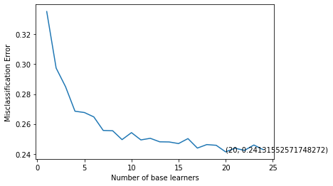

```python
# plotting the error as k increases
error = [1 - x for x in cv_scores]                                              #error corresponds to each nu of estimator
optimal_learners = base_ln[error.index(min(error))]                             #Selection of optimal nu of n_estimator corresponds to minimum error.
plt.plot(base_ln, error)                                                        #Plot between each nu of estimator and misclassification error
xy = (optimal_learners, min(error))
plt.annotate('(%s, %s)' % xy, xy = xy, textcoords='data')
plt.xlabel("Number of base learners")
plt.ylabel("Misclassification Error")
plt.show()
```

```python
# Training the best model and calculating error on test data .
clf = RandomForestClassifier(n_estimators = optimal_learners)
clf.fit(X_train, y_train)
clf.score(X_test, y_test)
```

```
0.7793715846994536
```

```python
result = clf.predict(X_test)
```

```
[[2607  144   63]
 [ 411  411   62]
 [ 206   83  405]]
0.7793715846994536
```

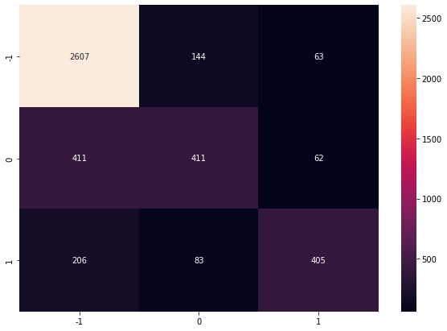

```python
# Print and plot Confusion matirx to get an idea of how the distribution of the prediction is, among all the classes.
result =  clf.predict(X_test)

conf_mat = confusion_matrix(y_test, result)

print(conf_mat)

print(metrics.f1_score(y_test, result,average='micro'))

df_cm = pd.DataFrame(conf_mat, index = [i for i in ["-1","0","1"]  ],
                  columns = [i for i in ["-1","0","1"] ]);
plt.figure(figsize = (10,7));
sns.heatmap(df_cm, annot=True, fmt='g');
```

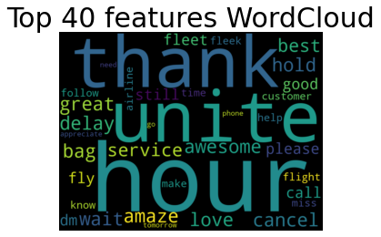

```python
all_features = vectorizer.get_feature_names()                                #Instantiate the feature from the vectorizer
Top_features=''                                                              #Addition of top 40 feature into top_feature after training the model
feat=clf.feature_importances_
features=np.argsort(feat)[::-1]
for i in features[0:40]:
    Top_features+=all_features[i]
    Top_features+=' '



wordcloud = WordCloud(background_color="Black",width=1000,
                          height=750).generate(Top_features)

# Display the generated image:
plt.imshow(wordcloud, interpolation='bilinear')
plt.figure(1, figsize=(30, 30), frameon='equal')
plt.title('Top 40 features WordCloud', fontsize=30)
plt.axis("off")
plt.show()
```

### **Summary**:

- After the basic EDA, data pre-processing was done. This consisted of Html tag removal, Tokenization, Removing the numbers, Removal of Special Characters and Punctuations, Removal of stopwords, Conversion to lowercase and Lemmatizing.
- Word clouds were produced to note the frequently used words in positive and negative tweets.
- Sentiment analysis was done using simple Vader and TextBlob libraries.
- After that, CountVectorizer and TfidfVectorizer were used and modeling was done. During this, vectorized column was used to fit the column. Cross-validation was done to ascertain model performance. Confusion matrices were made. Top 40 features were plotted as word clouds for both CountVectorizer and TfidfVectorizer.

### **Conclusion**:

- The EDA phase revealed a few insights. The majority of tweets were negative hinting at the fact that more people tweet about negative experiences than positive. Unhappiness with Customer service is the leading cause of negative tweets. Airlines being a retail customer service, improving customer service should improve the sentiment about the airlines.
- Smaller niche players seem to have better percentage positive tweets as compared to larger airlines. While the cause behind this is not known from this dataset, the larger airlines should look into the customer service experience with the small airlines and scout for areas of improvement.
- Delta seems to have a severe issue with late flights, while United seems to have a problem with checked-in bags.
- The Word cloud for positive and negative tweets are as distinct and clear as night and day! The management of airlines should track these words and look for improvement areas and strengthen what is going well already.
- Vader and TextBlob tools performed relatively poorly. Vader had an accuracy of 57%. A huge numbers of tweets that were negative but Vader prediction was positive. TextBlob also performed poorly (accuracy 54%) and it had the same misclassification problem as Vader.
- With CountVectorizer, the best model had an accuracy of 78%. Misclassifications were fewer.
- TfidfVectorizer's best model also had an accuracy of 78% with a small percentage of misclassifications.
- Top 40 word clouds for these two, had many words in common. This is expected.
- With both CountVectorizer and TfidfVectorizer, neutral tweets were misclassified as positive or negative. This suggests that there is room for further improvement in these algorithms. These misclassified tweets can be investigated to help improve model building in the future.